# STAT 4620 Final Project

Luke Dinan

12/6/2021

```r
knitr::opts_chunk$set(cache = T)
```

```r
options(scipen=999)
library(tidyverse)
library(magrittr)
library(glmnet)
library(data.table)
library(dbarts)
library(readr)
library(randomForest)
library(caret)
library(gbm)
library(corrplot)
```

```r
load("Ames/ames.Rdata")
train$Garage.Yr.Blt <- as.numeric(train$Garage.Yr.Blt)
test <- rbind(train[1,], test)
test <- test[-1,]
# Remove order/pid
train <- train[,-c(1, 2)]
test <- test[,-c(1, 2)]
```

# Background

The data set contains information from the Ames Assessor’s Office used in computing assessed values for individual residential properties sold in Ames, IA from 2006 to 2010.

Tab characters are used to separate variables in the data file. The data has 82 columns which include 23 nominal, 23 ordinal, 14 discrete, and 20 continuous variables (and 2 additional observation identifiers). 2 columns - order and pid - are for identification and are removed for the prediction.

### EDA Results

Our early EDA results involved cleaning the data and finding relationships among the predictors and response variable.

To start, a large amount of the data included NA values for columns that did not have relevant information. For example, if the house did not have a pool, the pool square footage was encoded as NA. The below code fixes this in both the training and testing set for categorical variables.

### Data Preparation

##### Replace NA Categorical

Training Data: replace categorical NA with more descriptive value

```r
train$Alley <- ifelse(is.na(train$Alley), "None", train$Alley)
train$Fireplace.Qu <- ifelse(is.na(train$Fireplace.Qu), "None", train$Fireplace.Qu)
train$Bsmt.Qual <- ifelse(is.na(train$Bsmt.Qual), "No Basement", train$Bsmt.Qual)
train$Bsmt.Cond <- ifelse(is.na(train$Bsmt.Cond), "No Basement", train$Bsmt.Cond)
train$Bsmt.Exposure <- ifelse(is.na(train$Bsmt.Exposure), "No Basement", train$Bsmt.Exposure)
train$BsmtFin.Type.1 <- ifelse(is.na(train$BsmtFin.Type.1), "No Basement", train$BsmtFin.Type.1)
train$BsmtFin.Type.2 <- ifelse(is.na(train$BsmtFin.Type.2), "No Basement", train$BsmtFin.Type.2)
train$Pool.QC <- ifelse(is.na(train$Pool.QC), "No Pool", train$Pool.QC)
train$Garage.Type <- ifelse(is.na(train$Garage.Type), "No Garage", train$Garage.Type)
train$Garage.Finish <- ifelse(is.na(train$Garage.Finish), "No Garage", train$Garage.Finish)
train$Garage.Qual <- ifelse(is.na(train$Garage.Qual), "No Garage", train$Garage.Qual)
train$Garage.Cond <- ifelse(is.na(train$Garage.Cond), "No Garage", train$Garage.Cond)
train$Fence <- ifelse(is.na(train$Fence), "No Fence", train$Fence)
train$Misc.Feature <- ifelse(is.na(train$Misc.Feature), "None", train$Misc.Feature)
```

Testing Data: replace categorical NA with more descriptive value

```r
test$Alley <- ifelse(is.na(test$Alley), "None", test$Alley)
test$Fireplace.Qu <- ifelse(is.na(test$Fireplace.Qu), "None", test$Fireplace.Qu)
test$Bsmt.Qual <- ifelse(is.na(test$Bsmt.Qual), "No Basement", test$Bsmt.Qual)
test$Bsmt.Cond <- ifelse(is.na(test$Bsmt.Cond), "No Basement", test$Bsmt.Cond)
test$Bsmt.Exposure <- ifelse(is.na(test$Bsmt.Exposure), "No Basement", test$Bsmt.Exposure)
test$BsmtFin.Type.1 <- ifelse(is.na(test$BsmtFin.Type.1), "No Basement", test$BsmtFin.Type.1)
test$BsmtFin.Type.2 <- ifelse(is.na(test$BsmtFin.Type.2), "No Basement", test$BsmtFin.Type.2)
test$Pool.QC <- ifelse(is.na(test$Pool.QC), "No Pool", test$Pool.QC)
test$Garage.Type <- ifelse(is.na(test$Garage.Type), "No Garage", test$Garage.Type)
test$Garage.Finish <- ifelse(is.na(test$Garage.Finish), "No Garage", test$Garage.Finish)
test$Garage.Qual <- ifelse(is.na(test$Garage.Qual), "No Garage", test$Garage.Qual)
test$Garage.Cond <- ifelse(is.na(test$Garage.Cond), "No Garage", test$Garage.Cond)
test$Fence <- ifelse(is.na(test$Fence), "No Fence", test$Fence)
test$Misc.Feature <- ifelse(is.na(test$Misc.Feature), "None", test$Misc.Feature)
```

Next, the continuous NAs were imputed with the median value.

##### Impute Continuous Nulls

Training Data: impute missing values with the median

```r
train$Lot.Frontage[is.na(train$Lot.Frontage)]<-median(train$Lot.Frontage,na.rm=TRUE)
train$Garage.Yr.Blt[is.na(train$Garage.Yr.Blt)]<-median(train$Garage.Yr.Blt,na.rm=TRUE)
train$Mas.Vnr.Area[is.na(train$Mas.Vnr.Area)]<-median(train$Mas.Vnr.Area,na.rm=TRUE)
train$Bsmt.Full.Bath[is.na(train$Bsmt.Full.Bath)]<-median(train$Bsmt.Full.Bath,na.rm=TRUE)
train$Bsmt.Half.Bath[is.na(train$Bsmt.Half.Bath)]<-median(train$Bsmt.Half.Bath,na.rm=TRUE)
train$BsmtFin.SF.1[is.na(train$BsmtFin.SF.1)]<-median(train$BsmtFin.SF.1,na.rm=TRUE)
train$BsmtFin.SF.2[is.na(train$BsmtFin.SF.2)]<-median(train$BsmtFin.SF.2,na.rm=TRUE)
train$Bsmt.Unf.SF[is.na(train$Bsmt.Unf.SF)]<-median(train$Bsmt.Unf.SF,na.rm=TRUE)
train$Total.Bsmt.SF[is.na(train$Total.Bsmt.SF)]<-median(train$Total.Bsmt.SF,na.rm=TRUE)
train$Garage.Cars[is.na(train$Garage.Cars)]<-median(train$Garage.Cars,na.rm=TRUE)
train$Garage.Area[is.na(train$Garage.Area)]<-median(train$Garage.Area,na.rm=TRUE)
```

Test Data: impute missing values with the median

```r
test$Lot.Frontage[is.na(test$Lot.Frontage)]<-median(test$Lot.Frontage,na.rm=TRUE)
test$Garage.Yr.Blt[is.na(test$Garage.Yr.Blt)]<-median(test$Garage.Yr.Blt,na.rm=TRUE)
test$Mas.Vnr.Area[is.na(test$Mas.Vnr.Area)]<-median(test$Mas.Vnr.Area,na.rm=TRUE)
test$Bsmt.Full.Bath[is.na(test$Bsmt.Full.Bath)]<-median(test$Bsmt.Full.Bath,na.rm=TRUE)
test$Bsmt.Half.Bath[is.na(test$Bsmt.Half.Bath)]<-median(test$Bsmt.Half.Bath,na.rm=TRUE)
test$BsmtFin.SF.1[is.na(test$BsmtFin.SF.1)]<-median(test$BsmtFin.SF.1,na.rm=TRUE)
test$BsmtFin.SF.2[is.na(test$BsmtFin.SF.2)]<-median(test$BsmtFin.SF.2,na.rm=TRUE)
test$Bsmt.Unf.SF[is.na(test$Bsmt.Unf.SF)]<-median(test$Bsmt.Unf.SF,na.rm=TRUE)
test$Total.Bsmt.SF[is.na(test$Total.Bsmt.SF)]<-median(test$Total.Bsmt.SF,na.rm=TRUE)
test$Garage.Cars[is.na(test$Garage.Cars)]<-median(test$Garage.Cars,na.rm=TRUE)
test$Garage.Area[is.na(test$Garage.Area)]<-median(test$Garage.Area,na.rm=TRUE)
```

No null values for train or test set

```r
sapply(train, function(y) sum(length(which(is.na(y)))))
```

```
##     MS.SubClass       MS.Zoning    Lot.Frontage        Lot.Area          Street
##               0               0               0               0               0
##           Alley       Lot.Shape    Land.Contour       Utilities      Lot.Config
##               0               0               0               0               0
##      Land.Slope    Neighborhood     Condition.1     Condition.2       Bldg.Type
##               0               0               0               0               0
##     House.Style    Overall.Qual    Overall.Cond      Year.Built  Year.Remod.Add
##               0               0               0               0               0
##      Roof.Style       Roof.Matl    Exterior.1st    Exterior.2nd    Mas.Vnr.Type
##               0               0               0               0               0
##    Mas.Vnr.Area      Exter.Qual      Exter.Cond      Foundation       Bsmt.Qual
##               0               0               0               0               0
##       Bsmt.Cond   Bsmt.Exposure  BsmtFin.Type.1    BsmtFin.SF.1  BsmtFin.Type.2
##               0               0               0               0               0
##    BsmtFin.SF.2     Bsmt.Unf.SF   Total.Bsmt.SF         Heating      Heating.QC
##               0               0               0               0               0
##     Central.Air      Electrical     X1st.Flr.SF     X2nd.Flr.SF Low.Qual.Fin.SF
##               0               0               0               0               0
##     Gr.Liv.Area  Bsmt.Full.Bath  Bsmt.Half.Bath       Full.Bath       Half.Bath
##               0               0               0               0               0
##   Bedroom.AbvGr   Kitchen.AbvGr    Kitchen.Qual   TotRms.AbvGrd      Functional
##               0               0               0               0               0
##      Fireplaces    Fireplace.Qu     Garage.Type   Garage.Yr.Blt   Garage.Finish
##               0               0               0               0               0
##     Garage.Cars     Garage.Area     Garage.Qual     Garage.Cond     Paved.Drive
##               0               0               0               0               0
##    Wood.Deck.SF   Open.Porch.SF  Enclosed.Porch     X3Ssn.Porch    Screen.Porch
##               0               0               0               0               0
##       Pool.Area         Pool.QC           Fence    Misc.Feature        Misc.Val
##               0               0               0               0               0
##         Mo.Sold         Yr.Sold       Sale.Type  Sale.Condition       SalePrice
##               0               0               0               0               0
```

```r
sapply(test, function(y) sum(length(which(is.na(y)))))
```

```
##     MS.SubClass       MS.Zoning    Lot.Frontage        Lot.Area          Street
##               0               0               0               0               0
##           Alley       Lot.Shape    Land.Contour       Utilities      Lot.Config
##               0               0               0               0               0
##      Land.Slope    Neighborhood     Condition.1     Condition.2       Bldg.Type
##               0               0               0               0               0
##     House.Style    Overall.Qual    Overall.Cond      Year.Built  Year.Remod.Add
##               0               0               0               0               0
##      Roof.Style       Roof.Matl    Exterior.1st    Exterior.2nd    Mas.Vnr.Type
##               0               0               0               0               0
##    Mas.Vnr.Area      Exter.Qual      Exter.Cond      Foundation       Bsmt.Qual
##               0               0               0               0               0
##       Bsmt.Cond   Bsmt.Exposure  BsmtFin.Type.1    BsmtFin.SF.1  BsmtFin.Type.2
##               0               0               0               0               0
##    BsmtFin.SF.2     Bsmt.Unf.SF   Total.Bsmt.SF         Heating      Heating.QC
##               0               0               0               0               0
##     Central.Air      Electrical     X1st.Flr.SF     X2nd.Flr.SF Low.Qual.Fin.SF
##               0               0               0               0               0
##     Gr.Liv.Area  Bsmt.Full.Bath  Bsmt.Half.Bath       Full.Bath       Half.Bath
##               0               0               0               0               0
##   Bedroom.AbvGr   Kitchen.AbvGr    Kitchen.Qual   TotRms.AbvGrd      Functional
##               0               0               0               0               0
##      Fireplaces    Fireplace.Qu     Garage.Type   Garage.Yr.Blt   Garage.Finish
##               0               0               0               0               0
##     Garage.Cars     Garage.Area     Garage.Qual     Garage.Cond     Paved.Drive
##               0               0               0               0               0
##    Wood.Deck.SF   Open.Porch.SF  Enclosed.Porch     X3Ssn.Porch    Screen.Porch
##               0               0               0               0               0
##       Pool.Area         Pool.QC           Fence    Misc.Feature        Misc.Val
##               0               0               0               0               0
##         Mo.Sold         Yr.Sold       Sale.Type  Sale.Condition       SalePrice
##               0               0               0               0               0
```

The following identifies the columns that could have problematic encoding. The goal is to decrease the number of predictors by eliminating sparse categories and encoding ordinal variables numerically. This is explained for each category.

##### MS Subclass

Change type of MS Subclass to Factor

```r
train$MS.SubClass <- as.factor(train$MS.SubClass)
test$MS.SubClass <- as.factor(test$MS.SubClass)
```

```r
table(train$MS.Zoning)
```

```
##
## A (agr) C (all)      FV I (all)      RH      RL      RM
##       2      19     104       2      21    1836     360
```

##### MS Zoning

```r
train$MS.Zoning <- ifelse(train$MS.Zoning %in% c("A (agr)", "C (all)", "I (all)", "RH", "RM"), "other", train$MS.Zoning)
test$MS.Zoning <- ifelse(test$MS.Zoning %in% c("A (agr)", "C (all)", "I (all)", "RH", "RM"), "other", test$MS.Zoning)
```

```r
table(train$MS.Zoning)
```

```
##
##    FV other    RL
##   104   404  1836
```

##### Alley

Dummy Variable for has.alley: seems unlikely type of alley matters, so drop original alley column

```r
train$Has.Alley <- as.factor(ifelse(train$Alley == "None", 0, 1))
test$Has.Alley <- as.factor(ifelse(test$Alley == "None", 0, 1))
train <- select(train, -Alley)
test <- select(test, -Alley)
```

```r
table(train$has.alley)
```

```
## < table of extent 0 >
```

##### Lot.Shape

Lot Shape is ordinal, so we want to have values that are numeric to represent the ordering.

```r
train$Lot.Shape <- case_when(train$Lot.Shape == "Reg" ~ 0,
                             train$Lot.Shape == "IR1" ~ 1,
                             train$Lot.Shape == "IR2" ~ 2,
                             train$Lot.Shape == "IR3" ~ 3)
test$Lot.Shape <- case_when(test$Lot.Shape == "Reg" ~ 0,
                             test$Lot.Shape == "IR1" ~ 1,
                             test$Lot.Shape == "IR2" ~ 2,
                             test$Lot.Shape == "IR3" ~ 3)
```

#### Lot Config

```r
table(train$Lot.Config)
```

```
##
##  Corner CulDSac     FR2     FR3  Inside
##     416     144      59      11    1714
```

Dummy for Inside lot or not, as that is the most frequent value.

```r
train$Lot.Config <- ifelse(train$Lot.Config == "Inside", "Inside", "other")
test$Lot.Config <- ifelse(test$Lot.Config == "Inside", "Inside", "other")
```

```r
table(train$Lot.Config)
```

```
##
## Inside  other
##   1714    630
```

##### Land Slope

Again, Land Slope in ordinal, so encode appropriately.

```r
table(train$Land.Slope)
```

```
##
##  Gtl  Mod  Sev
## 2229  102   13
```

```r
train$Land.Slope <- case_when(train$Land.Slope == "Gtl" ~ 0,
                              train$Land.Slope == "Mod" ~ 1,
                              train$Land.Slope == "Sev" ~ 2)
test$Land.Slope <- case_when(test$Land.Slope == "Gtl" ~ 0,
                              test$Land.Slope == "Mod" ~ 1,
                              test$Land.Slope == "Sev" ~ 2)
```

##### Condition.1

Condition 1 has mostly normal values, so include a dummy for normal or not.

```r
table(train$Condition.1)
```

```
##
## Artery  Feedr   Norm   PosA   PosN   RRAe   RRAn   RRNe   RRNn
##     75    135   2014     15     31     22     39      6      7
```

```r
train$Condition.1 <- ifelse(train$Condition.1 == "Norm", "norm", "other")
test$Condition.1 <- ifelse(test$Condition.1 == "Norm", "norm", "other")
```

```r
table(train$Condition.1)
```

```
##
##  norm other
##  2014   330
```

##### Condition.2

Condition 2 has almost all normal values, so it will include only a dummy variable for normal or not.

```r
table(train$Condition.2)
```

```
##
## Artery  Feedr   Norm   PosA   PosN   RRAe   RRAn   RRNn
##      3     12   2320      3      2      1      1      2
```

```r
train$Condition.2 <- as.factor(ifelse(train$Condition.2 == "Norm", "norm", "other"))
test$Condition.2 <- as.factor(ifelse(test$Condition.2 == "Norm", "norm", "other"))
```

```r
table(train$Condition.2)
```

```
##
##  norm other
##  2320    24
```

##### Roof Style

Only Gable and Hip have significant numbers, so we can include an “other” category for the rest.

```r
train$Roof.Style <- ifelse(train$Roof.Style %in% c("Flat", "Gambrel", "Mansard", "Shed"), "other", train$Roof.Style)
test$Roof.Style <- ifelse(test$Roof.Style %in% c("Flat", "Gambrel", "Mansard", "Shed"), "other", train$Roof.Style)
```

```r
table(train$Roof.Style)
```

```
##
## Gable   Hip other
##  1864   439    41
```

###### Roof Matl

```r
table(train$Roof.Matl)
```

```
##
## ClyTile CompShg Membran    Roll Tar&Grv WdShake WdShngl
##       1    2313       1       1      18       6       4
```

Include dummy variable for CompShg, as it is the only significant quantity

```r
train$Roof.Matl <- ifelse(train$Roof.Matl == "CompShg", "CompShg", "other")
test$Roof.Matl <- ifelse(test$Roof.Matl == "CompShg", "CompShg", "other")
```

```r
table(train$Roof.Matl)
```

```
##
## CompShg   other
##    2313      31
```

##### Exterior 1

Mostly Vinyl, HdBoard, and Plywood, so include these and a dummy for others

```r
table(train$Exterior.1st)
```

```
##
## AsbShng AsphShn BrkComm BrkFace  CBlock CemntBd HdBoard ImStucc MetalSd Plywood
##      36       1       5      68       2     105     371       1     354     174
## PreCast   Stone  Stucco VinylSd Wd Sdng WdShing
##       1       1      32     810     336      47
```

```r
train$Exterior.1st <- ifelse(train$Exterior.1st %in% c("VinylSd", "HdBoard", "Plywood"), train$Exterior.1st, "other")
test$Exterior.1st <- ifelse(test$Exterior.1st %in% c("VinylSd", "HdBoard", "Plywood"), test$Exterior.1st, "other")
```

```r
table(train$Exterior.1st)
```

```
##
## HdBoard   other Plywood VinylSd
##     371     989     174     810
```

##### Exterior 2

Similar to exterior 1, but CmentBd, HdBoard, MetalSd, Plywood, VinylSd, and Wd Sdng are high in frequency.

```r
table(train$Exterior.2nd)
```

```
##
## AsbShng AsphShn Brk Cmn BrkFace  CBlock CmentBd HdBoard ImStucc MetalSd   Other
##      30       3      18      38       2     105     343      12     351       1
## Plywood PreCast   Stone  Stucco VinylSd Wd Sdng Wd Shng
##     217       1       5      36     801     311      70
```

```r
train$Exterior.2nd <- ifelse(train$Exterior.2nd %in% c("CmentBd", "HdBoard", "MetalSd", "Plywood", "VinylSd", "Wd Sdng"), train$Exterior.2nd, "other")
test$Exterior.2nd <- ifelse(test$Exterior.2nd %in% c("CmentBd", "HdBoard", "MetalSd", "Plywood", "VinylSd", "Wd Sdng"), test$Exterior.2nd, "other")
```

```r
table(train$Exterior.2nd)
```

```
##
## CmentBd HdBoard MetalSd   other Plywood VinylSd Wd Sdng
##     105     343     351     216     217     801     311
```

##### Masonry Vnr Type

The only significant values are BrkFace and None. Include other for the rest.

```r
table(train$Mas.Vnr.Type)
```

```
##
##          BrkCmn BrkFace    None   Stone
##      19      21     689    1406     209
```

```r
train$Mas.Vnr.Type <- ifelse(train$Mas.Vnr.Type %in% c("BrkFace", "None"), train$Mas.Vnr.Type, "other")
test$Mas.Vnr.Type <- ifelse(test$Mas.Vnr.Type %in% c("BrkFace", "None"), test$Mas.Vnr.Type, "other")
```

```r
table(train$Mas.Vnr.Type)
```

```
##
## BrkFace    None   other
##     689    1406     249
```

##### Exter Qual

```r
table(train$Exter.Qual)
```

```
##
##   Ex   Fa   Gd   TA
##   79   28  783 1454
```

Again, ordinal, so encode appropriately.

```r
train$Exter.Qual <- case_when(train$Exter.Qual == "Ex" ~ 4,
                              train$Exter.Qual == "Gd" ~ 3,
                              train$Exter.Qual == "TA" ~ 2,
                              train$Exter.Qual == "Fa" ~ 1,
                              train$Exter.Qual == "Po" ~ 0)
test$Exter.Qual <- case_when(test$Exter.Qual == "Ex" ~ 4,
                              test$Exter.Qual == "Gd" ~ 3,
                              test$Exter.Qual == "TA" ~ 2,
                              test$Exter.Qual == "Fa" ~ 1,
                              test$Exter.Qual == "Po" ~ 0)
```

```r
table(train$Exter.Qual)
```

```
##
##    1    2    3    4
##   28 1454  783   79
```

##### Foundation

Slab, Stone, and Wood are infrequent, so replace those with other.

```r
table(train$Foundation)
```

```
##
## BrkTil CBlock  PConc   Slab  Stone   Wood
##    252    999   1037     42     10      4
```

```r
train$Foundation <- ifelse(train$Foundation %in% c("BrkTil", "CBlock", "PConc"), train$Foundation, "other")
test$Foundation <- ifelse(test$Foundation %in% c("BrkTil", "CBlock", "PConc"), test$Foundation, "other")
```

```r
table(train$Foundation)
```

```
##
## BrkTil CBlock  other  PConc
##    252    999     56   1037
```

##### Create Dummy Variable for whether house has a basement

```r
train$Has.Basement <- ifelse(train$Bsmt.Qual == "No Basement", 0, 1)
test$Has.Basement <- ifelse(test$Bsmt.Qual == "No Basement", 0, 1)
```

##### Bsmt Qual

```r
train$Bsmt.Qual <- ifelse(train$Bsmt.Qual == "", "No Basement", train$Bsmt.Qual)
test$Bsmt.Qual <- ifelse(test$Bsmt.Qual == "", "No Basement", test$Bsmt.Qual)
table(train$Bsmt.Qual)
```

```
##
##          Ex          Fa          Gd No Basement          Po          TA
##         201          69         982          65           2        1025
```

Again, Ordinal. This time, not having a basement is zero, as that seems to make sense in the heirarchy.

```r
train$Bsmt.Qual <- case_when(train$Bsmt.Qual == "Ex" ~ 5,
                             train$Bsmt.Qual == "Gd" ~ 4,
                             train$Bsmt.Qual == "TA" ~ 3,
                             train$Bsmt.Qual == "Fa" ~ 2,
                             train$Bsmt.Qual == "Po" ~ 1,
                             train$Bsmt.Qual == "No Basement" ~ 0)
test$Bsmt.Qual <- case_when(test$Bsmt.Qual == "Ex" ~ 5,
                             test$Bsmt.Qual == "Gd" ~ 4,
                             test$Bsmt.Qual == "TA" ~ 3,
                             test$Bsmt.Qual == "Fa" ~ 2,
                             test$Bsmt.Qual == "Po" ~ 1,
                             test$Bsmt.Qual == "No Basement" ~ 0)
```

```r
table(train$Bsmt.Qual)
```

```
##
##    0    1    2    3    4    5
##   65    2   69 1025  982  201
```

##### Bsmt Cond

Again, ordinal, and represent no basement as zero.

```r
train$Bsmt.Cond <- ifelse(train$Bsmt.Cond == "", "No Basement", train$Bsmt.Cond)
test$Bsmt.Cond <- ifelse(test$Bsmt.Cond == "", "No Basement", test$Bsmt.Cond)
table(train$Bsmt.Cond)
```

```
##
##          Ex          Fa          Gd No Basement          Po          TA
##           2          84         108          65           4        2081
```

```r
train$Bsmt.Cond <- case_when(train$Bsmt.Cond == "Ex" ~ 5,
                             train$Bsmt.Cond == "Gd" ~ 4,
                             train$Bsmt.Cond == "TA" ~ 3,
                             train$Bsmt.Cond == "Fa" ~ 2,
                             train$Bsmt.Cond == "Po" ~ 1,
                             train$Bsmt.Cond == "No Basement" ~ 0)
test$Bsmt.Cond <- case_when(test$Bsmt.Cond == "Ex" ~ 5,
                             test$Bsmt.Cond == "Gd" ~ 4,
                             test$Bsmt.Cond == "TA" ~ 3,
                             test$Bsmt.Cond == "Fa" ~ 2,
                             test$Bsmt.Cond == "Po" ~ 1,
                             test$Bsmt.Cond == "No Basement" ~ 0)
```

```r
table(train$Bsmt.Cond)
```

```
##
##    0    1    2    3    4    5
##   65    4   84 2081  108    2
```

##### Bsmt Exposure

Again, ordinal with No Basement as 0.

```r
train$Bsmt.Exposure <- ifelse(train$Bsmt.Exposure == "", "No Basement", train$Bsmt.Exposure)
test$Bsmt.Exposure <- ifelse(test$Bsmt.Exposure == "", "No Basement", test$Bsmt.Exposure)
table(train$Bsmt.Exposure)
```

```
##
##          Av          Gd          Mn          No No Basement
##         335         230         186        1526          67
```

```r
train$Bsmt.Exposure <- case_when(train$Bsmt.Exposure == "Gd" ~ 4,
                                 train$Bsmt.Exposure == "Av" ~ 3,
                                 train$Bsmt.Exposure == "Mn" ~ 2,
                                 train$Bsmt.Exposure == "No" ~ 1,
                                 train$Bsmt.Exposure == "No Basement" ~ 0)
test$Bsmt.Exposure <- case_when(test$Bsmt.Exposure == "Gd" ~ 4,
                                 test$Bsmt.Exposure == "Av" ~ 3,
                                 test$Bsmt.Exposure == "Mn" ~ 2,
                                 test$Bsmt.Exposure == "No" ~ 1,
                                 test$Bsmt.Exposure == "No Basement" ~ 0)
```

```r
table(train$Bsmt.Exposure)
```

```
##
##    0    1    2    3    4
##   67 1526  186  335  230
```

##### BsmtFin Type 2

Although Type 1 had an even distribution, type 2 has largely unfinished.

```r
table(train$BsmtFin.Type.2)
```

```
##
##                     ALQ         BLQ         GLQ         LwQ No Basement
##           1          45          55          26          68          64
##         Rec         Unf
##          88        1997
```

```r
train$BsmtFin.Type.2 <- ifelse(train$BsmtFin.Type.2 == "Unf", "Unf", "other")
test$BsmtFin.Type.2 <- ifelse(test$BsmtFin.Type.2 == "Unf", "Unf", "other")
```

```r
table(train$BsmtFin.Type.2)
```

```
##
## other   Unf
##   347  1997
```

##### Heating

Dummy variable for GasA

```r
table(train$Heating)
```

```
##
## Floor  GasA  GasW  Grav  OthW  Wall
##     1  2306    20     9     2     6
```

```r
train$Heating <- ifelse(train$Heating == "GasA", "GasA", "other")
test$Heating <- ifelse(test$Heating == "GasA", "GasA", "other")
```

```r
table(train$Heating)
```

```
##
##  GasA other
##  2306    38
```

##### Heating QC

Ordinal, so encode appropriately.

```r
table(train$Heating.QC)
```

```
##
##   Ex   Fa   Gd   Po   TA
## 1182   77  395    3  687
```

```r
train$Heating.QC <- case_when(train$Heating.QC == "Ex" ~ 4,
                              train$Heating.QC == "Gd" ~ 3,
                              train$Heating.QC == "TA" ~ 2,
                              train$Heating.QC == "Fa" ~ 1,
                              train$Heating.QC == "Po" ~ 0)
test$Heating.QC <- case_when(test$Heating.QC == "Ex" ~ 4,
                              test$Heating.QC == "Gd" ~ 3,
                              test$Heating.QC == "TA" ~ 2,
                              test$Heating.QC == "Fa" ~ 1,
                              test$Heating.QC == "Po" ~ 0)
```

```r
table(train$Heating.QC)
```

```
##
##    0    1    2    3    4
##    3   77  687  395 1182
```

##### Electrical

Only include Sbrkr or other.

```r
table(train$Electrical)
```

```
##
##       FuseA FuseF FuseP SBrkr
##     1   155    40     7  2141
```

```r
train$Electrical <- ifelse(train$Electrical == "SBrkr", "SBrkr", "other")
test$Electrical <- ifelse(test$Electrical == "SBrkr", "SBrkr", "other")
```

```r
table(train$Electrical)
```

```
##
## other SBrkr
##   203  2141
```

```r
train$Kitchen.Qual <- case_when(train$Kitchen.Qual == "Ex" ~ 4,
                                train$Kitchen.Qual == "Gd" ~ 3,
                                train$Kitchen.Qual == "TA" ~ 2,
                                train$Kitchen.Qual == "Fa" ~ 1,
                                train$Kitchen.Qual == "Po" ~ 0)
test$Kitchen.Qual <- case_when(test$Kitchen.Qual == "Ex" ~ 4,
                                test$Kitchen.Qual == "Gd" ~ 3,
                                test$Kitchen.Qual == "TA" ~ 2,
                                test$Kitchen.Qual == "Fa" ~ 1,
                                test$Kitchen.Qual == "Po" ~ 0)
```

```r
table(train$Kitchen.Qual)
```

```
##
##    0    1    2    3    4
##    1   56 1212  920  155
```

##### Functional

Dummy variable for functionality less than typical

```r
table(train$Functional)
```

```
##
## Maj1 Maj2 Min1 Min2  Mod  Sal  Sev  Typ
##   18    6   52   60   27    2    1 2178
```

```r
train$Functional <- ifelse(train$Functional == "Typ", "Typ", "BelowTyp")
test$Functional <- ifelse(test$Functional == "Typ", "Typ", "BelowTyp")
```

```r
table(train$Functional)
```

```
##
## BelowTyp      Typ
##      166     2178
```

```r
train$Has.Fireplace <- ifelse(train$Fireplace.Qu == "None", 1, 0)
test$Has.Fireplace <- ifelse(test$Fireplace.Qu == "None", 1, 0)
```

##### Fireplace Qu

```r
train$Fireplace.Qu <- case_when(train$Fireplace.Qu == "Ex" ~ 5,
                                train$Fireplace.Qu == "Gd" ~ 4,
                                train$Fireplace.Qu == "TA" ~ 3,
                                train$Fireplace.Qu == "Fa" ~ 2,
                                train$Fireplace.Qu == "Po" ~ 1,
                                train$Fireplace.Qu == "None" ~ 0)
test$Fireplace.Qu <- case_when(test$Fireplace.Qu == "Ex" ~ 5,
                                test$Fireplace.Qu == "Gd" ~ 4,
                                test$Fireplace.Qu == "TA" ~ 3,
                                test$Fireplace.Qu == "Fa" ~ 2,
                                test$Fireplace.Qu == "Po" ~ 1,
                                test$Fireplace.Qu == "None" ~ 0)
```

```r
table(train$Fireplace.Qu)
```

```
##
##    0    1    2    3    4    5
## 1155   38   54  486  577   34
```

```r
train$Has.Garage <- ifelse(train$Garage.Type == "No Garage", 1, 0)
test$Has.Garage <- ifelse(test$Garage.Type == "No Garage", 1, 0)
```

##### Garage Finish

Ordinal, so encode accordingly.

```r
train$Garage.Finish <- ifelse(train$Garage.Finish == "", "No Garage", train$Garage.Finish)
test$Garage.Finish <- ifelse(test$Garage.Finish == "", "No Garage", test$Garage.Finish)
table(train$Garage.Finish)
```

```
##
##       Fin No Garage       RFn       Unf
##       571       127       650       996
```

```r
train$Garage.Finish <- case_when(train$Garage.Finish == "Fin" ~ 3,
                                 train$Garage.Finish == "RFn" ~ 2,
                                 train$Garage.Finish == "Unf" ~ 1,
                                 train$Garage.Finish == "No Garage" ~ 0)
test$Garage.Finish <- case_when(test$Garage.Finish == "Fin" ~ 3,
                                 test$Garage.Finish == "RFn" ~ 2,
                                 test$Garage.Finish == "Unf" ~ 1,
                                 test$Garage.Finish == "No Garage" ~ 0)
```

```r
table(train$Garage.Finish)
```

```
##
##   0   1   2   3
## 127 996 650 571
```

##### Garage Quality

```r
train$Garage.Qual <- ifelse(train$Garage.Qual == "", "No Garage", train$Garage.Qual)
test$Garage.Qual <- ifelse(test$Garage.Qual == "", "No Garage", test$Garage.Qual)
table(train$Garage.Qual)
```

```
##
##        Ex        Fa        Gd No Garage        Po        TA
##         2       101        17       127         4      2093
```

```r
train$Garage.Qual <- case_when(train$Garage.Qual == "Ex" ~ 5,
                               train$Garage.Qual == "Gd" ~ 4,
                               train$Garage.Qual == "TA" ~ 3,
                               train$Garage.Qual == "Fa" ~ 2,
                               train$Garage.Qual == "Po" ~ 1,
                               train$Garage.Qual == "No Garage" ~ 0)
test$Garage.Qual <- case_when(test$Garage.Qual == "Ex" ~ 5,
                               test$Garage.Qual == "Gd" ~ 4,
                               test$Garage.Qual == "TA" ~ 3,
                               test$Garage.Qual == "Fa" ~ 2,
                               test$Garage.Qual == "Po" ~ 1,
                               test$Garage.Qual == "No Garage" ~ 0)
```

```r
table(train$Garage.Qual)
```

```
##
##    0    1    2    3    4    5
##  127    4  101 2093   17    2
```

#### Paved Drive

There are not many unpaved, so only include a dummy for paved or unpaved.

```r
table(train$Paved.Drive)
```

```
##
##    N    P    Y
##  179   49 2116
```

```r
train$Paved.Drive <- ifelse(train$Paved.Drive == "Y", "Paved", "Unpaved")
test$Paved.Drive <- ifelse(test$Paved.Drive == "Y", "Paved", "Unpaved")
```

```r
table(train$Paved.Drive)
```

```
##
##   Paved Unpaved
##    2116     228
```

##### Pool Area and Quality don’t appear relevant because most don’t have a pool; create a dummy for having a pool instead

```r
train$Has.Pool <- ifelse(train$Pool.QC == "No Pool", 0, 1)
test$Has.Pool <- ifelse(test$Pool.QC == "No Pool", 0, 1)
```

Drop columns:

```r
train <- select(train, -Pool.QC, -Pool.Area)
test <- select(test, -Pool.QC, -Pool.Area)
```

##### Fence

Ordinal, so encode appropriately with no fence as 0.

```r
table(train$Fence)
```

```
##
##    GdPrv     GdWo    MnPrv     MnWw No Fence
##       91       87      269       11     1886
```

```r
train$Fence <- case_when(train$Fence == "GdPrv" ~ 4,
                         train$Fence == "MnPrv" ~ 3,
                         train$Fence == "GdWo" ~ 2,
                         train$Fence == "MnWw" ~ 1,
                         train$Fence == "No Fence" ~ 0)
test$Fence <- case_when(test$Fence == "GdPrv" ~ 4,
                         test$Fence == "MnPrv" ~ 3,
                         test$Fence == "GdWo" ~ 2,
                         test$Fence == "MnWw" ~ 1,
                         test$Fence == "No Fence" ~ 0)
```

```r
table(train$Fence)
```

```
##
##    0    1    2    3    4
## 1886   11   87  269   91
```

##### Misc Feature

Create dummy for having a miscellaneous feature

```r
table(train$Misc.Feature)
```

```
##
## Gar2 None Othr Shed
##    4 2264    3   73
```

```r
train$Misc.Feature <- ifelse(train$Misc.Feature == "None", 0, 1)
test$Misc.Feature <- ifelse(test$Misc.Feature == "None", 0, 1)
```

```r
table(train$Misc.Feature)
```

```
##
##    0    1
## 2264   80
```

##### Sale Type

Eliminate sparse categories, those other than New and Wd

```r
table(train$Sale.Type)
```

```
##
##   COD   Con ConLD ConLI ConLw   CWD   New   Oth   VWD   WD
##    69     5    20     7     6    10   193     6     1  2027
```

```r
train$Sale.Type <- ifelse(train$Sale.Type %in% c("New", "WD "), train$Sale.Type, "other")
test$Sale.Type <- ifelse(test$Sale.Type %in% c("New", "WD "), test$Sale.Type, "other")
```

```r
table(train$Sale.Type)
```

```
##
##   New other   WD
##   193   124  2027
```

##### Filter > 4000 sq. ft. observations

```r
train <- train[train$Gr.Liv.Area < 4000,]
```

##### Eliminate Irrelevant Variables

Utilities

```r
table(train$Utilities)
```

```
##
## AllPub NoSeWa NoSewr
##   2339      1      2
```

```r
train <- train %>% select(-Utilities)
test <- test %>% select(-Utilities)
```

Wood Deck Sq Ft.: many zero values, so include a dummy instead

```r
length(train$Wood.Deck.SF[train$Wood.Deck.SF == 0])
```

```
## [1] 1212
```

```r
train$Has.Wood.Deck <- ifelse(train$Wood.Deck.SF == 0, 0, 1)
test$Has.Wood.Deck <- ifelse(test$Wood.Deck.SF == 0, 0, 1)
```

Open Porch Sq. Ft.: Same

```r
length(train$Open.Porch.SF[train$Open.Porch.SF == 0])
```

```
## [1] 1054
```

```r
train$Has.Open.Porch <- ifelse(train$Open.Porch.SF == 0, 0, 1)
test$Has.Open.Porch <- ifelse(test$Open.Porch.SF == 0, 0, 1)
```

Enclosed Porch

```r
length(train$Enclosed.Porch[train$Enclosed.Porch == 0])
```

```
## [1] 1964
```

```r
train$Has.Enclosed.Porch <- ifelse(train$Enclosed.Porch == 0, 0, 1)
test$Has.Enclosed.Porch <- ifelse(test$Enclosed.Porch == 0, 0, 1)
```

3-Ssn Porch

```r
length(train$X3Ssn.Porch[train$X3Ssn.Porch == 0])
```

```
## [1] 2313
```

```r
train$Has.X3Ssn.Porch <- ifelse(train$X3Ssn.Porch == 0 , 0, 1)
test$Has.X3Ssn.Porch <- ifelse(test$X3Ssn.Porch == 0 , 0, 1)
```

Screen Porch

```r
length(train$Screen.Porch[train$Screen.Porch == 0])
```

```
## [1] 2133
```

```r
train$Has.Screen.Porch <- ifelse(train$Screen.Porch == 0, 0, 1)
test$Has.Screen.Porch <- ifelse(test$Screen.Porch == 0, 0, 1)
```

Remove Variables:

```r
train <- train %>% select(-Wood.Deck.SF, -Open.Porch.SF, -Enclosed.Porch, -X3Ssn.Porch, -Screen.Porch)
test <- test %>% select(-Wood.Deck.SF, -Open.Porch.SF, -Enclosed.Porch, -X3Ssn.Porch, -Screen.Porch)
```

### EDA Visualization

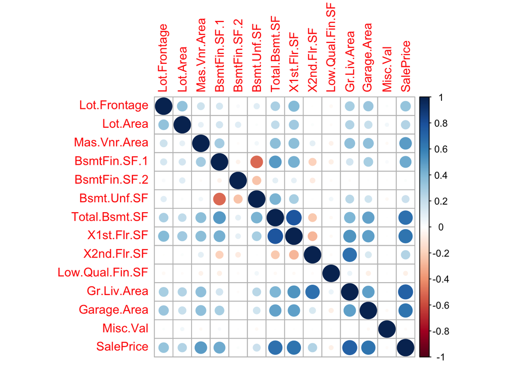

```r
# create df of only continuous predictors
ames.cont <- train %>%
  dplyr::select(Lot.Frontage, Lot.Area, Mas.Vnr.Area, BsmtFin.SF.1, BsmtFin.SF.2, Bsmt.Unf.SF, Total.Bsmt.SF, X1st.Flr.SF, X2nd.Flr.SF, Low.Qual.Fin.SF, Gr.Liv.Area, Garage.Area, Misc.Val, SalePrice)

# correlation matrix
corrplot(cor(ames.cont))
```

```r
correlations <- as.data.frame(as.table(cor(ames.cont))) %>%
  rename(correlation = Freq) %>%
  filter(correlation < -0.25 | correlation > 0.5 & correlation != 1) %>%
  arrange(correlation)

correlations[seq_len(nrow(correlations)) %% 2 == 1,]
```

```
##             Var1          Var2 correlation
## 1    Bsmt.Unf.SF  BsmtFin.SF.1  -0.5029289
## 3    X2nd.Flr.SF   X1st.Flr.SF  -0.2831133
## 5  Total.Bsmt.SF  BsmtFin.SF.1   0.5068028
## 7    Gr.Liv.Area   X1st.Flr.SF   0.5285813
## 9      SalePrice   X1st.Flr.SF   0.6415400
## 11     SalePrice   Garage.Area   0.6468513
## 13     SalePrice Total.Bsmt.SF   0.6585562
## 15   Gr.Liv.Area   X2nd.Flr.SF   0.6591914
## 17     SalePrice   Gr.Liv.Area   0.7231188
## 19   X1st.Flr.SF Total.Bsmt.SF   0.7766561
```

The following plot displays the increase in SalePrice as 1st Floor Sq Footage increases.

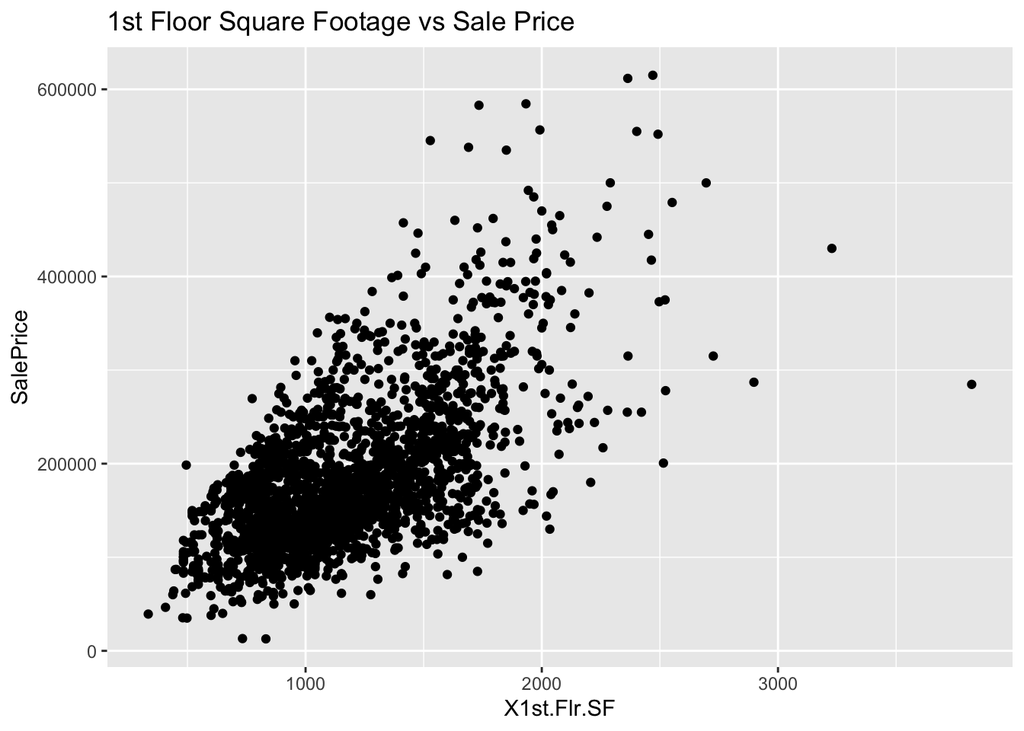

```r
ggplot(train, aes(x = X1st.Flr.SF, y = SalePrice)) + geom_point() + ggtitle("1st Floor Square Footage vs Sale Price")
```

Code to create model matrix that works for categories that are in the training data but not the test data. For these categories, a columns of 0’s is included. This does not impact the results but ensures that the predict function can be used.

```r
train <- as.data.frame(unclass(train), stringsAsFactors = TRUE)
test <- as.data.frame(unclass(test), stringsAsFactors = TRUE)
x_train = model.matrix(SalePrice~., train)[,-1]
x_test = model.matrix(SalePrice~., test)[,-1]
y_train = train$SalePrice
y_test = test$SalePrice
tr <- data.frame(x_train)
te <- data.frame(x_test)
# find columns not in other data set
for (col in colnames(tr)) {
  if (!(col %in% colnames(te))) {
    print(col)
    te[[col]] <- rep(0, nrow(te))
  }
}
```

```
## [1] "MS.SubClass150"
## [1] "NeighborhoodGreens"
## [1] "NeighborhoodGrnHill"
## [1] "NeighborhoodLandmrk"
## [1] "BsmtFin.Type.1ALQ"
## [1] "Garage.CondEx"
## [1] "Garage.CondFa"
```

```r
for (col in colnames(te)) {
  if (!(col %in% colnames(tr))) {
    print(col)
    tr[[col]] <- rep(0, nrow(tr))
  }
}
# make sure columns are aligned the same
col_str <- dput(colnames(tr))
```

```
## c("MS.SubClass30", "MS.SubClass40", "MS.SubClass45", "MS.SubClass50",
## "MS.SubClass60", "MS.SubClass70", "MS.SubClass75", "MS.SubClass80",
## "MS.SubClass85", "MS.SubClass90", "MS.SubClass120", "MS.SubClass150",
## "MS.SubClass160", "MS.SubClass180", "MS.SubClass190", "MS.Zoningother",
## "MS.ZoningRL", "Lot.Frontage", "Lot.Area", "StreetPave", "Lot.Shape",
## "Land.ContourHLS", "Land.ContourLow", "Land.ContourLvl", "Lot.Configother",
## "Land.Slope", "NeighborhoodBlueste", "NeighborhoodBrDale", "NeighborhoodBrkSide",
## "NeighborhoodClearCr", "NeighborhoodCollgCr", "NeighborhoodCrawfor",
## "NeighborhoodEdwards", "NeighborhoodGilbert", "NeighborhoodGreens",
## "NeighborhoodGrnHill", "NeighborhoodIDOTRR", "NeighborhoodLandmrk",
## "NeighborhoodMeadowV", "NeighborhoodMitchel", "NeighborhoodNAmes",
## "NeighborhoodNoRidge", "NeighborhoodNPkVill", "NeighborhoodNridgHt",
## "NeighborhoodNWAmes", "NeighborhoodOldTown", "NeighborhoodSawyer",
## "NeighborhoodSawyerW", "NeighborhoodSomerst", "NeighborhoodStoneBr",
## "NeighborhoodSWISU", "NeighborhoodTimber", "NeighborhoodVeenker",
## "Condition.1other", "Condition.2other", "Bldg.Type2fmCon", "Bldg.TypeDuplex",
## "Bldg.TypeTwnhs", "Bldg.TypeTwnhsE", "House.Style1.5Unf", "House.Style1Story",
## "House.Style2.5Fin", "House.Style2.5Unf", "House.Style2Story",
## "House.StyleSFoyer", "House.StyleSLvl", "Overall.Qual", "Overall.Cond",
## "Year.Built", "Year.Remod.Add", "Roof.StyleHip", "Roof.Styleother",
## "Roof.Matlother", "Exterior.1stother", "Exterior.1stPlywood",
## "Exterior.1stVinylSd", "Exterior.2ndHdBoard", "Exterior.2ndMetalSd",
## "Exterior.2ndother", "Exterior.2ndPlywood", "Exterior.2ndVinylSd",
## "Exterior.2ndWd.Sdng", "Mas.Vnr.TypeNone", "Mas.Vnr.Typeother",
## "Mas.Vnr.Area", "Exter.Qual", "Exter.CondFa", "Exter.CondGd",
## "Exter.CondPo", "Exter.CondTA", "FoundationCBlock", "Foundationother",
## "FoundationPConc", "Bsmt.Qual", "Bsmt.Cond", "Bsmt.Exposure",
## "BsmtFin.Type.1ALQ", "BsmtFin.Type.1BLQ", "BsmtFin.Type.1GLQ",
## "BsmtFin.Type.1LwQ", "BsmtFin.Type.1No.Basement", "BsmtFin.Type.1Rec",
## "BsmtFin.Type.1Unf", "BsmtFin.SF.1", "BsmtFin.Type.2Unf", "BsmtFin.SF.2",
## "Bsmt.Unf.SF", "Total.Bsmt.SF", "Heatingother", "Heating.QC",
## "Central.AirY", "ElectricalSBrkr", "X1st.Flr.SF", "X2nd.Flr.SF",
## "Low.Qual.Fin.SF", "Gr.Liv.Area", "Bsmt.Full.Bath", "Bsmt.Half.Bath",
## "Full.Bath", "Half.Bath", "Bedroom.AbvGr", "Kitchen.AbvGr", "Kitchen.Qual",
## "TotRms.AbvGrd", "FunctionalTyp", "Fireplaces", "Fireplace.Qu",
## "Garage.TypeAttchd", "Garage.TypeBasment", "Garage.TypeBuiltIn",
## "Garage.TypeCarPort", "Garage.TypeDetchd", "Garage.TypeNo.Garage",
## "Garage.Yr.Blt", "Garage.Finish", "Garage.Cars", "Garage.Area",
## "Garage.Qual", "Garage.CondEx", "Garage.CondFa", "Garage.CondGd",
## "Garage.CondNo.Garage", "Garage.CondPo", "Garage.CondTA", "Paved.DriveUnpaved",
## "Fence", "Misc.Feature", "Misc.Val", "Mo.Sold", "Yr.Sold", "Sale.Typeother",
## "Sale.TypeWD.", "Sale.ConditionAdjLand", "Sale.ConditionAlloca",
## "Sale.ConditionFamily", "Sale.ConditionNormal", "Sale.ConditionPartial",
## "Has.Alley1", "Has.Basement", "Has.Fireplace", "Has.Garage",
## "Has.Pool", "Has.Wood.Deck", "Has.Open.Porch", "Has.Enclosed.Porch",
## "Has.X3Ssn.Porch", "Has.Screen.Porch")
```

```r
te <- te %>% select(col_str)
# makes model.matrix from data frame
x_train <- makeModelMatrixFromDataFrame(tr, drop = FALSE)
x_test <- makeModelMatrixFromDataFrame(te, drop = FALSE)
```

# Analysis

### LASSO

Train LASSO model on train data, test with test data:

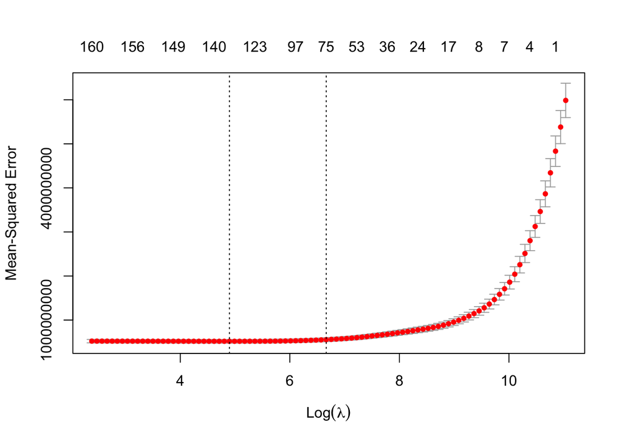

```r
# fit a cross-validated model
lasso.cv = cv.glmnet(x_train, y_train,alpha=1)
lambda.cv = lasso.cv$lambda.min
plot(lasso.cv)
```

```r
# fit model with specific lambda
lasso.best = glmnet(x_train, y_train,alpha=1,lambda=lambda.cv)
lasso.coef <- data.frame(as.matrix(coef(lasso.best))) %>% arrange(desc(abs(s0)))
head(lasso.coef, 10)
```

```
##                             s0
## (Intercept)         -364048.31
## NeighborhoodGrnHill  108222.67
## MS.SubClass150       -49661.90
## NeighborhoodStoneBr   35561.56
## Has.Basement         -34714.25
## NeighborhoodNridgHt   30963.38
## Has.Pool              24072.25
## NeighborhoodNoRidge   21677.63
## NeighborhoodBrDale    21293.72
## MS.SubClass120       -21065.81
```

```r
# look at model performance on training data
preds.train.lasso = predict(lasso.best, newx = x_train)
residuals.train = y_train - preds.train.lasso
residuals.squared.train = residuals.train^2
MSE.train = mean(residuals.squared.train)
RSS.train = sum(residuals.squared.train)
paste("Training MSE: ", MSE.train)
```

```
## [1] "Training MSE:  444689995.012868"
```

```r
paste("Training RSS: ", RSS.train)
```

```
## [1] "Training RSS:  1041463968320.14"
```

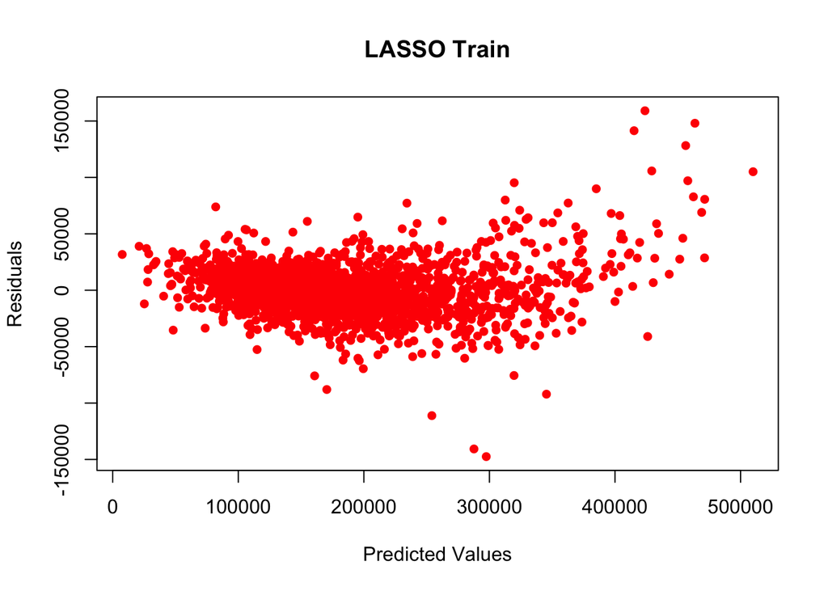

```r
# plot fitted values vs residuals. This would be better if we knew stdev in order to calcualte standardized residuals but no closed from available for this
plot(preds.train.lasso,residuals.train, xlab = "Predicted Values", ylab = "Residuals", main = "LASSO Train", pch = 16, col = "red")
```

```r
# evaluate model performance on test data
preds.lasso = predict(lasso.best, newx = x_test)
residuals = y_test - preds.lasso
residuals.squared = residuals^2
MSE_LASSO = mean(residuals.squared)
RSS_LASSO = sum(residuals.squared)
paste("MSE: ", MSE_LASSO)
```

```
## [1] "MSE:  1266011975.92856"
```

```r
paste("RSS: ", RSS_LASSO)
```

```
## [1] "RSS:  741883017894.138"
```

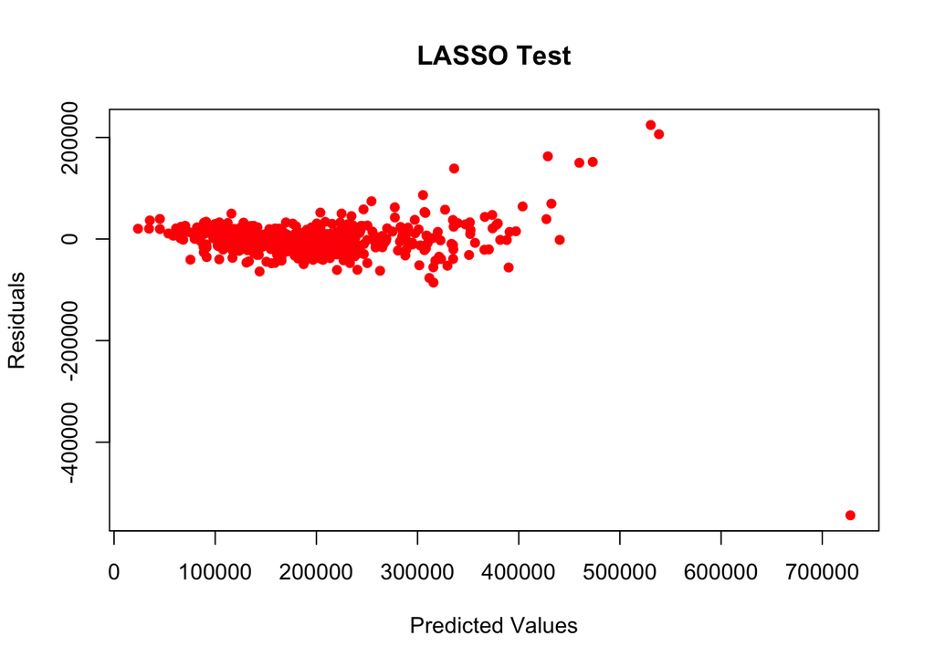

```r
# plot fitted values vs residuals
plot(preds.lasso, residuals, xlab = "Predicted Values", ylab = "Residuals", main = "LASSO Test", pch = 16, col = "red")
```

Appears that model works well overall but we get extraneous results when our predicted house prices are really high. There is one data point that makes the predicted values. It seems worthwhile to check the MSE and plot without this outlier.

```r
MSE_LASSO_removed = mean(residuals.squared[-which.min(residuals)])
RSS_LASSO_removed = sum(residuals.squared[-which.min(residuals)])
paste("MSE: ", MSE_LASSO_removed)
```

```
## [1] "MSE:  762389170.691385"
```

```r
paste("RSS: ", RSS_LASSO_removed)
```

```
## [1] "RSS:  445997664854.46"
```

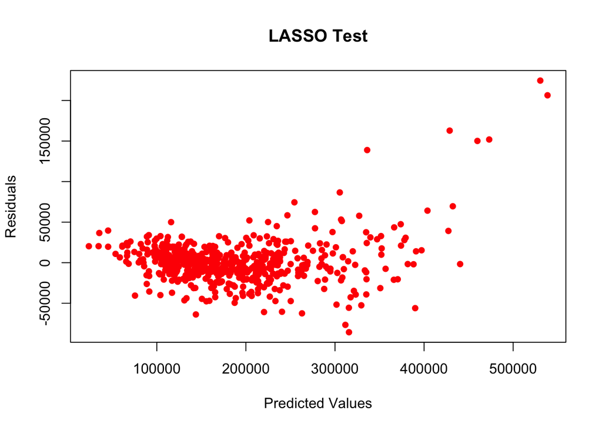

```r
plot(preds.lasso[-447], residuals[-447], xlab = "Predicted Values", ylab = "Residuals", main = "LASSO Test", pch = 16, col = "red")
```

There looks to be some higher squared residuals among the higher predictions, but overall it doesn’t seem too concerning. It makes sense that the model would predict sale prices around the median more accurately.

For the future, it seems to make sense to remove the outlier data point. For some reason, this home was priced far below what would be expected. This should give us a better representation of the results.

```r
x_test <- x_test[-which.min(residuals),]
y_test <- y_test[-which.min(residuals)]
test <- test[-which.min(residuals),]
preds.lasso <- preds.lasso[-which.min(residuals)]
MSE_LASSO <- MSE_LASSO_removed
RSS_LASSO <- RSS_LASSO_removed
```

### Ridge

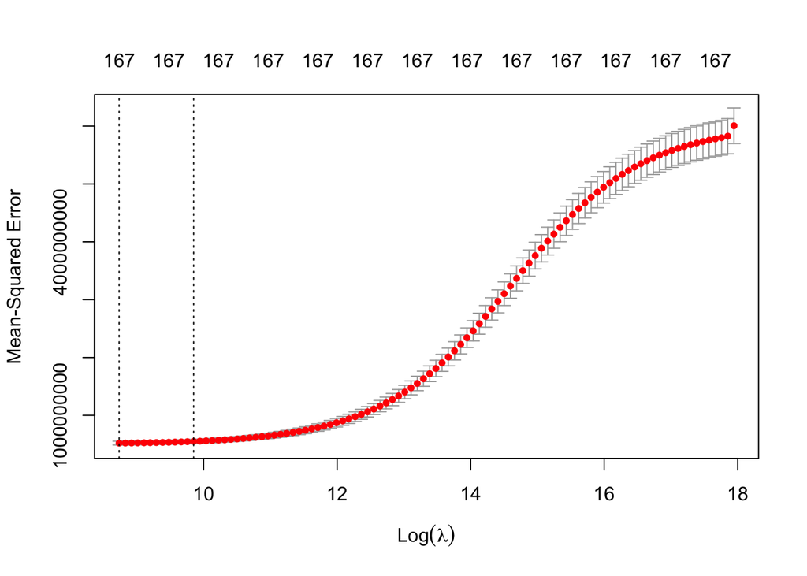

```r
ridge_cv=cv.glmnet(x_train,y_train,alpha=0)
plot(ridge_cv)
```

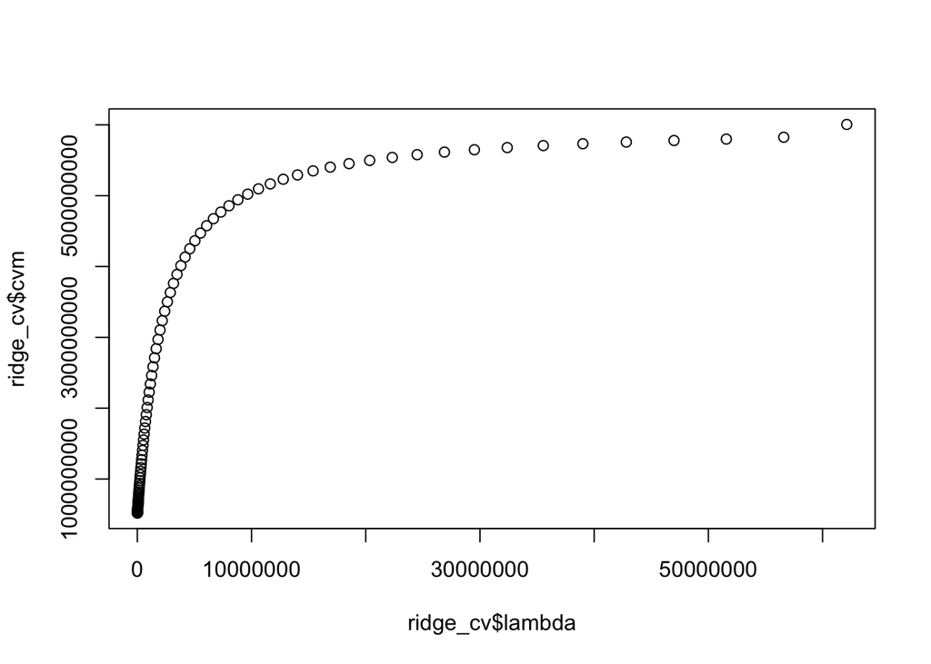

```r
plot(ridge_cv$lambda,ridge_cv$cvm)
```

```r
lambda_cv=ridge_cv$lambda.min
paste0("Best Lambda: ", lambda_cv)
```

```
## [1] "Best Lambda: 6211.93526324311"
```

```r
ridge.best = glmnet(x_train,y_train,alpha=0,lambda=lambda_cv)
ridge.coef <- data.frame(as.matrix(coef(ridge.best))) %>% arrange(desc(abs(s0)))
head(ridge.coef, 10)
```

```
##                            s0
## NeighborhoodGrnHill 105784.63
## MS.SubClass150      -45265.14
## NeighborhoodStoneBr  32858.65
## Has.Pool             28622.42
## NeighborhoodNridgHt  26432.48
## (Intercept)          24017.85
## NeighborhoodNoRidge  20980.06
## NeighborhoodBrDale   17635.43
## NeighborhoodNPkVill  16953.02
## House.Style2.5Fin   -16208.72
```

```r
preds.ridge = predict(ridge.best, newx=x_test)
residuals = y_test - preds.ridge
MSE_Ridge <- mean((residuals)^2)
RSS_Ridge <- sum((residuals)^2)
paste0("MSE Ridge: ", MSE_Ridge)
```

```
## [1] "MSE Ridge: 821616459.993337"
```

```r
paste0("RSS Ridge: ", RSS_Ridge)
```

```
## [1] "RSS Ridge: 480645629096.102"
```

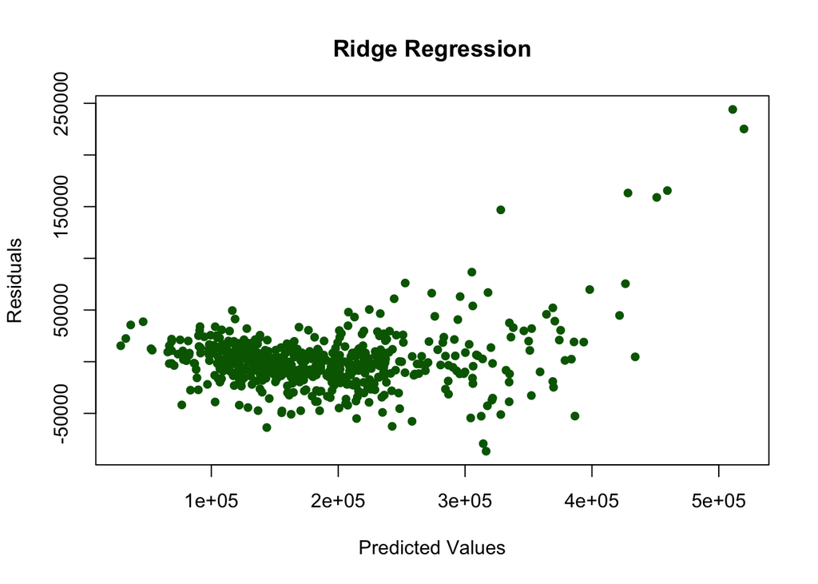

```r
# plot fitted values vs residuals
plot(preds.ridge, residuals, xlab = "Predicted Values", ylab = "Residuals", main = "Ridge Regression", pch = 16, col = "DarkGreen")
```

The predictions for Ridge Regression look similar to LASSO.

```r
predictions <- data.frame("LASSO" = as.vector(preds.lasso), "Ridge" = as.vector(preds.ridge))
metrics <- data.frame("LASSO" = c(MSE_LASSO, RSS_LASSO, sqrt(MSE_LASSO)), "Ridge" = c(MSE_Ridge, RSS_Ridge, sqrt(MSE_Ridge)), row.names = c("MSE", "RSS", "sqrt(MSE)"))
```

Get Data Frame for Coefficients

```r
lasso.coef <- as.matrix(coef(lasso.best))
ridge.coef <- as.matrix(coef(ridge.best))
coefficients <- data.frame("Feature" = rownames(lasso.coef), "LASSO" = as.vector(lasso.coef), "Ridge" = as.vector(ridge.coef), "TrainingSD" = append(0, apply(x_train, 2, sd)), row.names = c())
head(coefficients, 10)
```

```
##          Feature         LASSO     Ridge TrainingSD
## 1    (Intercept) -3.640483e+05 24017.848 0.00000000
## 2  MS.SubClass30  4.200313e+03  2858.047 0.21343581
## 3  MS.SubClass40  0.000000e+00  -428.623 0.04616578
## 4  MS.SubClass45  3.237857e+03  2032.853 0.08238928
## 5  MS.SubClass50  1.345640e+03  2001.817 0.29416624
## 6  MS.SubClass60  0.000000e+00  2452.004 0.39539827
## 7  MS.SubClass70  2.634580e+03  4423.357 0.19929660
## 8  MS.SubClass75  9.877449e+02  9636.888 0.08734945
## 9  MS.SubClass80 -1.059779e+02 -4320.356 0.19430815
## 10 MS.SubClass85 -9.392581e+00 -2531.072 0.13117651
```

### Random Forest

```r
ctrl.rf <- trainControl(method = 'cv',
                           number = 5,
                           search = 'random',
                           savePredictions = T)
rf.mod <- train(SalePrice~., data = train, method = 'rf', trControl = ctrl.rf, tuneLength = 10, ntree = 500)
print(rf.mod)
```

```
## Random Forest
##
## 2342 samples
##   80 predictor
##
## No pre-processing
## Resampling: Cross-Validated (5 fold)
## Summary of sample sizes: 1874, 1872, 1874, 1874, 1874
## Resampling results across tuning parameters:
##
##   mtry  RMSE      Rsquared   MAE
##     5   26765.08  0.9013254  16913.24
##    56   22983.46  0.9168690  14738.89
##    79   23193.52  0.9146813  14832.30
##    83   23185.39  0.9146283  14847.52
##   111   23331.24  0.9129886  14901.47
##   120   23399.31  0.9120479  14944.90
##   124   23471.04  0.9114173  14971.78
##   151   23734.82  0.9089828  15158.03
##   154   23765.09  0.9088377  15117.21
##
## RMSE was used to select the optimal model using the smallest value.
## The final value used for the model was mtry = 56.
```

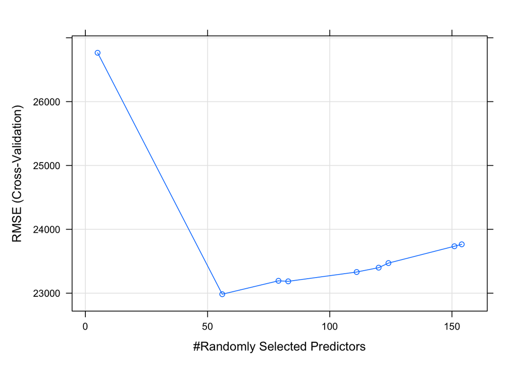

```r
plot(rf.mod)
```

```r
as.numeric(rf.mod$bestTune)
```

```
## [1] 56
```

```r
# train Random Forest
test <- rbind(train[1,], test)
test <- test[-1,]
rf.ames = randomForest(SalePrice ~ ., data = train, mtry = as.numeric(rf.mod$bestTune), importance = TRUE)
rf.pred = predict(rf.ames, newdata = test)
```

```r
residuals <- test$SalePrice-rf.pred
MSE_rf <- mean((residuals)^2)
paste0("MSE_rf: ", MSE_rf)
```

```
## [1] "MSE_rf: 870651748.19843"
```

```r
RSS_rf <- sum((residuals)^2)
paste0("RSS_rf", RSS_rf)
```

```
## [1] "RSS_rf509331272696.082"
```

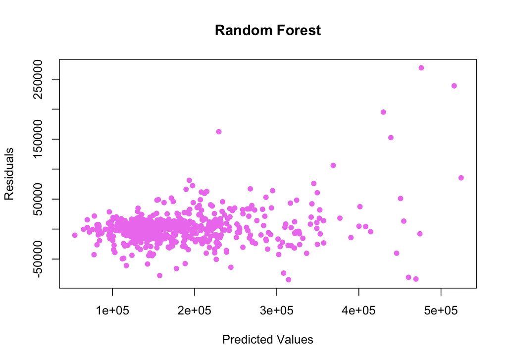

```r
plot(rf.pred, residuals, xlab = "Predicted Values", ylab = "Residuals", main = "Random Forest", pch = 16, col = "violet")
```

```r
importance <- importance(rf.ames)
as.data.frame(importance) %>% arrange(desc(IncNodePurity))
```

```
##                        %IncMSE IncNodePurity
## Overall.Qual       40.81958909  5.771460e+12
## Neighborhood       43.24992437  1.521934e+12
## Gr.Liv.Area        69.36206140  1.465126e+12
## Exter.Qual         10.21976683  9.198829e+11
## X1st.Flr.SF        32.93398711  5.306389e+11
## Garage.Cars         9.33620912  4.371298e+11
## Total.Bsmt.SF      30.84941131  4.339365e+11
## Kitchen.Qual       15.93182578  3.935544e+11
## Garage.Area        19.44483356  2.438424e+11
## BsmtFin.SF.1       26.82598163  2.362890e+11
## Lot.Area           17.29526988  2.159653e+11
## Bsmt.Qual           8.77746545  2.012657e+11
## Year.Built          7.66275186  1.877970e+11
## Full.Bath          12.17498698  1.490902e+11
## MS.SubClass        27.10149425  1.453202e+11
## X2nd.Flr.SF        19.77960563  1.135077e+11
## Year.Remod.Add     16.70390568  9.138975e+10
## Mas.Vnr.Area        4.11280090  8.300614e+10
## Bsmt.Unf.SF         7.95481637  6.398275e+10
## Exterior.2nd       11.01438863  5.177847e+10
## BsmtFin.Type.1     18.28478596  5.085315e+10
## Garage.Yr.Blt      10.12645116  5.018157e+10
## Lot.Frontage        7.48523219  4.683509e+10
## Bsmt.Exposure      11.94007233  4.472572e+10
## TotRms.AbvGrd       6.46446601  4.301941e+10
## Mo.Sold             5.24022087  4.235106e+10
## Overall.Cond       20.21546676  3.527305e+10
## Garage.Type         9.91073094  3.174157e+10
## Fireplace.Qu       11.45749145  3.005225e+10
## Sale.Condition      5.25657621  2.517821e+10
## Fireplaces          7.90455722  1.783726e+10
## Yr.Sold             2.20521550  1.609868e+10
## Bedroom.AbvGr       6.59135272  1.559310e+10
## Central.Air         9.82334534  1.470039e+10
## Bsmt.Full.Bath      7.39174788  1.319354e+10
## Mas.Vnr.Type        4.76028020  1.300035e+10
## Heating.QC          6.75286549  1.282709e+10
## Exterior.1st        8.72767390  1.269158e+10
## Foundation          6.11605944  1.260008e+10
```

[output cut: 26 more lines]

```
## Has.Alley           1.00424239  2.131844e+09
## Electrical          2.17881646  1.921481e+09
## Has.Garage          1.90388447  1.616315e+09
## Has.X3Ssn.Porch     1.09448896  1.566796e+09
## BsmtFin.Type.2      1.61778046  1.559505e+09
## Has.Basement        3.01731188  1.339861e+09
## Roof.Matl          -1.65512748  1.154445e+09
## Misc.Val            0.08151394  1.071867e+09
## Bsmt.Half.Bath      0.98835636  1.043062e+09
## Low.Qual.Fin.SF     0.45270905  9.037184e+08
## Heating            -0.15050130  7.210004e+08
## Misc.Feature        1.09133544  5.858752e+08
## Condition.2         0.46612833  5.207745e+08
## Has.Pool            1.00100150  4.904981e+08
## Street              0.87217485  5.401100e+07
```

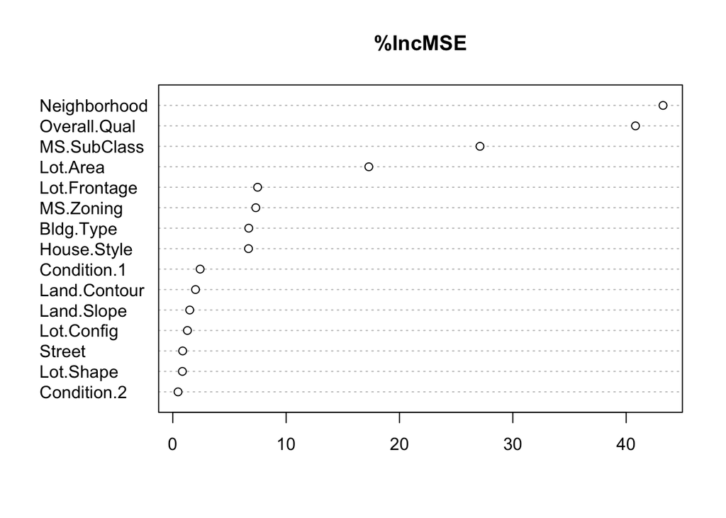

```r
dotchart(sort(importance[0:15,1]), main="%IncMSE")
```

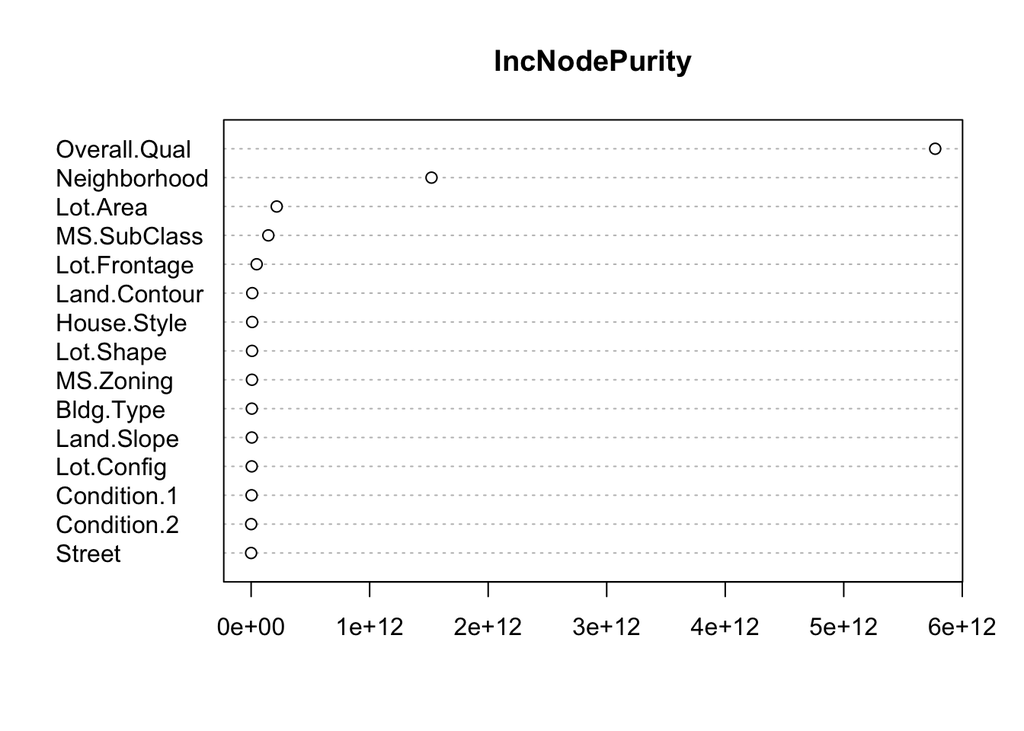

```r
dotchart(sort(importance[0:15,2]), main="IncNodePurity")
```

```r
predictions$RandomForest <- rf.pred
metrics$RandomForest <- c(MSE_rf, RSS_rf, sqrt(MSE_rf))
```

### Gradient Boosting

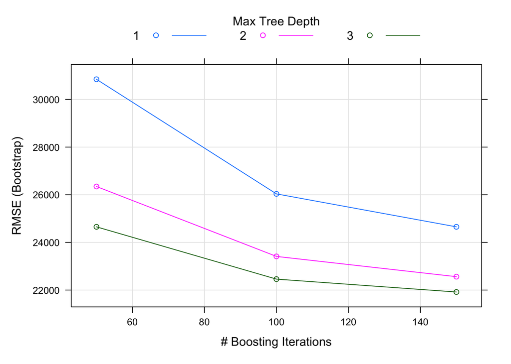

```r
ctrl.gbm <- trainControl(method = 'cv',
                           number = 5,
                           search = 'random',
                           savePredictions = T)
gbm.mod <- train(SalePrice~., data = train, method = 'gbm')
print(gbm.mod)
plot(gbm.mod)
```

```r
gbm.mod$bestTune
```

```
##   n.trees interaction.depth shrinkage n.minobsinnode
## 9     150                 3       0.1             10
```

```r
gbm.ames <- gbm(SalePrice ~ ., data = train, n.trees = as.numeric(gbm.mod$bestTune$n.trees), interaction.depth = as.numeric(gbm.mod$bestTune$interaction.depth), shrinkage = as.numeric(gbm.mod$bestTune$shrinkage), n.minobsinnode = as.numeric(gbm.mod$bestTune$n.minobsinnode))
```

```
## Distribution not specified, assuming gaussian ...
```

```r
gbm.pred <- predict(gbm.ames, test)
```

```
## Using 150 trees...
```

```r
residuals <- test$SalePrice-gbm.pred
MSE_gbm <- mean((residuals)^2)
paste0("MSE_rf: ", MSE_gbm)
```

```
## [1] "MSE_rf: 632718392.511002"
```

```r
RSS_gbm <- sum((residuals)^2)
paste0("RSS_rf: ", RSS_gbm)
```

```
## [1] "RSS_rf: 370140259618.936"
```

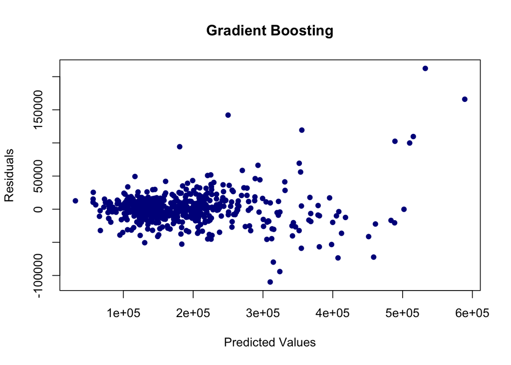

```r
plot(gbm.pred, residuals, xlab = "Predicted Values", ylab = "Residuals", main = "Gradient Boosting", pch = 16, col = "darkblue")
```

The predictions for Gradient Boosting look similar to Random Forest.

```r
predictions$GradientBoost <- gbm.pred
metrics$GradientBoost <- c(MSE_gbm, RSS_gbm, sqrt(MSE_gbm))
```

Feature Importances:

```r
s <- summary(gbm.ames)
```

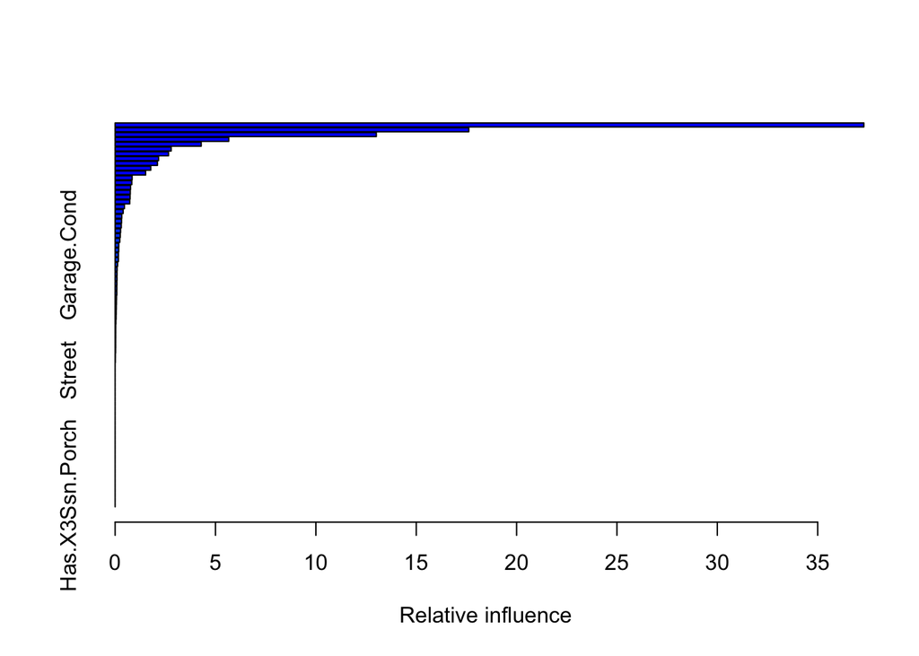

```r
s[1:15,]
```

```
##                           var    rel.inf
## Overall.Qual     Overall.Qual 37.3000558
## Gr.Liv.Area       Gr.Liv.Area 17.6175067
## Neighborhood     Neighborhood 13.0120021
## Total.Bsmt.SF   Total.Bsmt.SF  5.6595162
## Kitchen.Qual     Kitchen.Qual  4.2879964
## BsmtFin.SF.1     BsmtFin.SF.1  2.7923339
## Garage.Area       Garage.Area  2.6596457
## X1st.Flr.SF       X1st.Flr.SF  2.1629961
## Bsmt.Qual           Bsmt.Qual  2.1071426
## Garage.Cars       Garage.Cars  1.7742959
## Exter.Qual         Exter.Qual  1.5190847
## Year.Remod.Add Year.Remod.Add  0.8464313
## Lot.Area             Lot.Area  0.8287556
## X2nd.Flr.SF       X2nd.Flr.SF  0.7671256
## MS.SubClass       MS.SubClass  0.7533302
```

```r
i <- data.frame(importance)
importances <- data.frame("Feature" = rownames(i), "RandomForest" = i$X.IncMSE)
importances <- importances %>% left_join(s, by = c("Feature" = "var")) %>% rename("GradientBoost" = "rel.inf") %>% replace_na(list(GradientBoost = 0))
```

```r
predictions$Actual <- test$SalePrice
```

```r
write.csv(predictions, "/Users/lukedinan/Documents/STAT 4620/STAT-4620-Project/predictions.csv")
write.csv(metrics, "/Users/lukedinan/Documents/STAT 4620/STAT-4620-Project/metrics.csv")
write.csv(importances, "/Users/lukedinan/Documents/STAT 4620/STAT-4620-Project/importances.csv")
write.csv(coefficients, "/Users/lukedinan/Documents/STAT 4620/STAT-4620-Project/coefficients.csv")
```